# ANOVAs

- Show All Code
- Hide All Code
- View Source

scripts, interpretations, plots

Author

Affiliation

Jürgen Schneider

DIPF

Published

July 18, 2023

# loading packages

```r
library(tidyverse)
library(palmerpenguins)
library(car)
library(report)
library(BFpack)
library(ggpubr)
library(rstatix)
library(bain)
```

# First data set

```r
glimpse(penguins)
```

```
Rows: 344
Columns: 8
$ species           <fct> Adelie, Adelie, Adelie, Adelie, Adelie, Adelie, Adel…
$ island            <fct> Torgersen, Torgersen, Torgersen, Torgersen, Torgerse…
$ bill_length_mm    <dbl> 39.1, 39.5, 40.3, NA, 36.7, 39.3, 38.9, 39.2, 34.1, …
$ bill_depth_mm     <dbl> 18.7, 17.4, 18.0, NA, 19.3, 20.6, 17.8, 19.6, 18.1, …
$ flipper_length_mm <int> 181, 186, 195, NA, 193, 190, 181, 195, 193, 190, 186…
$ body_mass_g       <int> 3750, 3800, 3250, NA, 3450, 3650, 3625, 4675, 3475, …
$ sex               <fct> male, female, female, NA, female, male, female, male…
$ year              <int> 2007, 2007, 2007, 2007, 2007, 2007, 2007, 2007, 2007…
```

# Assumptions

## Homogeneity of Variances

Assumption: “The variances of the populations that the samples come from are equal.”

The Levene test tests the **null hypothesis** that variance homogeneity exists. The **alternative hypothesis** assumes variance heterogeneity

### `leveneTest()` in `car` package

```r
leveneTest(body_mass_g ~ species, data = penguins)
```

```
Levene's Test for Homogeneity of Variance (center = median)
       Df F value   Pr(>F)
group   2  5.1203 0.006445 **
      339
---
Signif. codes:  0 '***' 0.001 '**' 0.01 '*' 0.05 '.' 0.1 ' ' 1
```

The p-value is below .05, this means we have to reject the null hypothesis. We therefore have evidence against the assumption that variance homogeneity exists.

### Bayesian alternative

A quick search didn’t yield any good results for functions.

## Normality

Assumption: “Each sample was drawn from a normally distributed population.”

### `qqPlot()` in `car` package

QQ plot (or quantile-quantile plot) draws the correlation between a given sample and the normal distribution. With normality, the data points should move along the diagonal line.

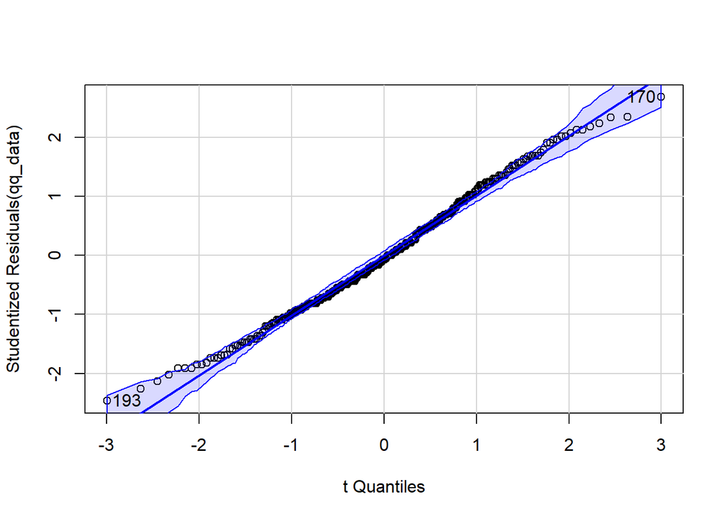

```
[1] 170 193
```

```r
qq_data <- aov(body_mass_g ~ species, data = penguins)
qqPlot(qq_data)
```

Do the data points move along the diagonal line? Well…

### `ggqqplot()` in `ggpubr` package

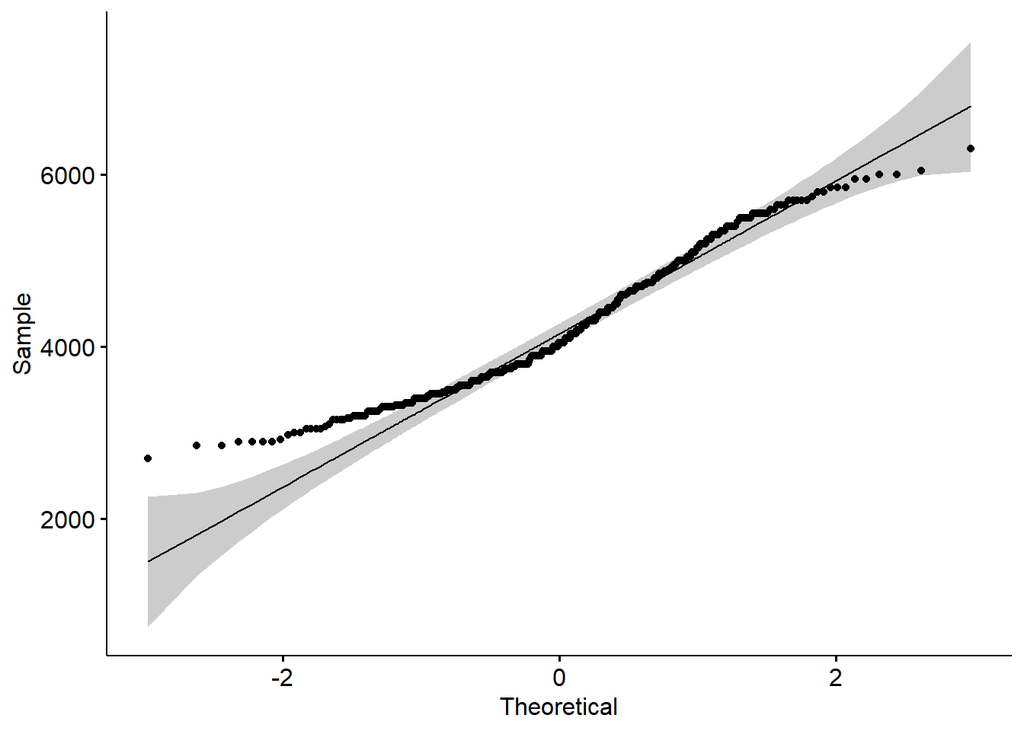

```r
ggqqplot(penguins$body_mass_g)
```

Do the data points move along the diagonal line? Well…

### Shapiro-Wilk Test

The Shapiro-Wilk Test tests the **null hypothesis** that the samples come from a normal distribution vs. the **alternative hypothesis** that the samples do not come from a normal distribution.

```r
shapiro.test(penguins$body_mass_g)
```

```
    Shapiro-Wilk normality test

data:  penguins$body_mass_g
W = 0.95921, p-value = 3.679e-08
```

The p-value is below .05, this means we have to reject the null hypothesis. We therefore have evidence against the assumption that normality of distributions exist. Please note that with large sample sizes, frequentistic tests will nearly always be significant.

In general, a one-way ANOVA is considered to be **fairly robust** against violations of the normality assumption as long as the sample sizes are sufficiently large.

If the normality assumption is severely violated or if you just want to be extra conservative, you have two choices:

1. Transform the response values of your data so that the distributions are more normally distributed.
2. Perform an equivalent non-parametric test such as a Kruskal-Wallis Test that doesn’t require the assumption of normality.

# ANOVA

There are several packages that realize an ANOVA.

## `aov()` in base R (`stats`)

```r
aov_model1 <- aov(body_mass_g ~ species, data = penguins)
summary(aov_model1)
```

```
             Df    Sum Sq  Mean Sq F value Pr(>F)
species       2 146864214 73432107   343.6 <2e-16 ***
Residuals   339  72443483   213698
---
Signif. codes:  0 '***' 0.001 '**' 0.01 '*' 0.05 '.' 0.1 ' ' 1
2 Beobachtungen als fehlend gelöscht
```

### Let’S get someone to explain what this means

```r
report(aov_model1)
```

```
The ANOVA (formula: body_mass_g ~ species) suggests that:

  - The main effect of species is statistically significant and large (F(2, 339)
= 343.63, p < .001; Eta2 = 0.67, 95% CI [0.63, 1.00])

Effect sizes were labelled following Field's (2013) recommendations.
```

### But wait, is there a Bayesian alternative?

Sure there is with the `BFpack()` package. Just put it on top of the `aov()` object. Easy.

```r
BF(aov_model1)
```

```
Call:
BF.lm(x = aov_model1)

Bayesian hypothesis test
Type: exploratory
Object: aov
Parameter: group means
Method: generalized adjusted fractional Bayes factors

Posterior probabilities:
        Pr(no effect) Pr(complement)
species             0              1
```

## `anova_test()` in `rstatix` package

```r
aov_model2 <- anova_test(body_mass_g ~ species, data = penguins)
aov_model2
```

```
ANOVA Table (type II tests)

   Effect DFn DFd       F        p p<.05  ges
1 species   2 339 343.626 2.89e-82     * 0.67
```

## `TukeyHSD()` in base R (`stats`)

```r
TukeyHSD(aov_model1)
```

```
  Tukey multiple comparisons of means
    95% family-wise confidence level

Fit: aov(formula = body_mass_g ~ species, data = penguins)

$species
                       diff       lwr       upr     p adj
Chinstrap-Adelie   32.42598 -126.5002  191.3522 0.8806666
Gentoo-Adelie    1375.35401 1243.1786 1507.5294 0.0000000
Gentoo-Chinstrap 1342.92802 1178.4810 1507.3750 0.0000000
```

## `tukey_hsd()` in `rstatix` package

```r
tukey_hsd(aov_model1)
```

```
# A tibble: 3 × 9
  term   group1 group2 null.value estimate conf.low conf.high p.adj p.adj.signif
* <chr>  <chr>  <chr>       <dbl>    <dbl>    <dbl>     <dbl> <dbl> <chr>
1 speci… Adelie Chins…          0     32.4    -127.      191. 0.881 ns
2 speci… Adelie Gentoo          0   1375.     1243.     1508. 0     ****
3 speci… Chins… Gentoo          0   1343.     1178.     1507. 0     ****
```

## Bayesian ANOVA with `bain` package

Examples see [introduction to bain](https://cran.r-project.org/web/packages/bain/vignettes/Introduction_to_bain.html).

```r
# execute an analysis of variance using lm() which, due to the -1, returns
# estimates of the means per group
bain_aov <- lm(body_mass_g ~ species-1, penguins)
# take a look at the estimated means and their names
coef(bain_aov)
```

```
   speciesAdelie speciesChinstrap    speciesGentoo
        3700.662         3733.088         5076.016
```

```r
# set a seed value
set.seed(100)
# test hypotheses with bain
bain_model <- bain(bain_aov, "speciesAdelie=speciesChinstrap=speciesGentoo;
                              speciesAdelie=speciesChinstrap<speciesGentoo;
                              speciesAdelie<speciesChinstrap<speciesGentoo")
# display the results
bain_model
```

```
Bayesian informative hypothesis testing for an object of class lm (ANOVA):

   Fit   Com   BF.u   BF.c   PMPa  PMPb  PMPc
H1 0.000 0.000 0.000  0.000  0.000 0.000 0.000
H2 0.005 0.000 21.136 21.136 0.836 0.805 0.824
H3 0.691 0.167 4.135  11.154 0.164 0.157 0.161
Hu                                 0.038
Hc 0.309 0.833 0.371                     0.014

Hypotheses:
  H1: speciesAdelie=speciesChinstrap=speciesGentoo
  H2: speciesAdelie=speciesChinstrap<speciesGentoo
  H3: speciesAdelie<speciesChinstrap<speciesGentoo

Note: BF.u denotes the Bayes factor of the hypothesis at hand versus the unconstrained hypothesis Hu. BF.c denotes the Bayes factor of the hypothesis at hand versus its complement. PMPa contains the posterior model probabilities of the hypotheses specified. PMPb adds Hu, the unconstrained hypothesis…
```

```r
# obtain the contrasts between the hypotheses
bain_model$BFmatrix
```

```
              H1            H2            H3
H1  1.000000e+00 4.348318e-149 2.222594e-148
H2 2.299740e+148  1.000000e+00  5.111388e+00
H3 4.499247e+147  1.956416e-01  1.000000e+00
```

```r
# obtain the descriptives table
summary(bain_model, ci = 0.95)
```

```
         Parameter   n Estimate       lb       ub
1    speciesAdelie 151 3700.662 3626.930 3774.395
2 speciesChinstrap  68 3733.088 3623.215 3842.962
3    speciesGentoo 123 5076.016 4994.321 5157.711
```

# Plot One-Way ANOVA

## Boxplot

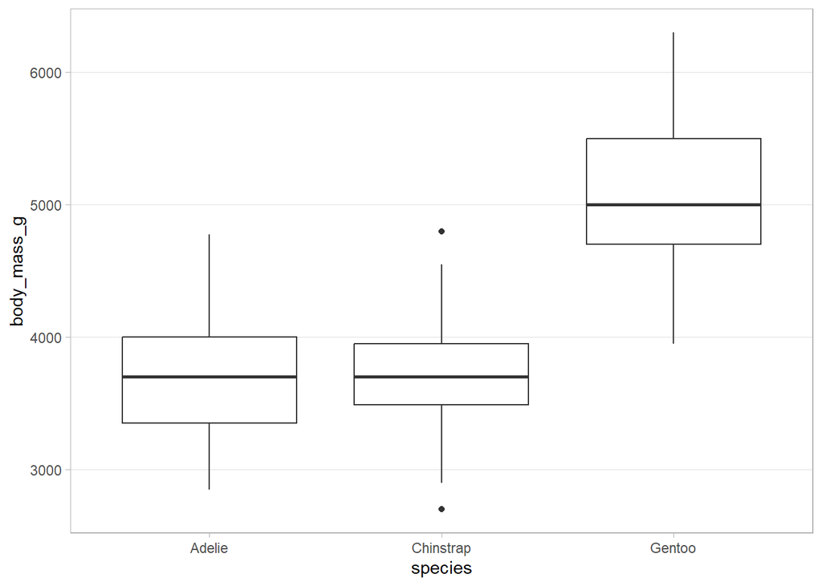

```r
ggplot(penguins, aes(x=species, y=body_mass_g)) +
  geom_boxplot() +
  theme_light() +
  theme(panel.grid.major.x = element_blank(),
        panel.grid.minor.y = element_blank())
```

In boxplots we don’t really see the distribution of the data. It might be bimodel without us knowing.

## Violin plot

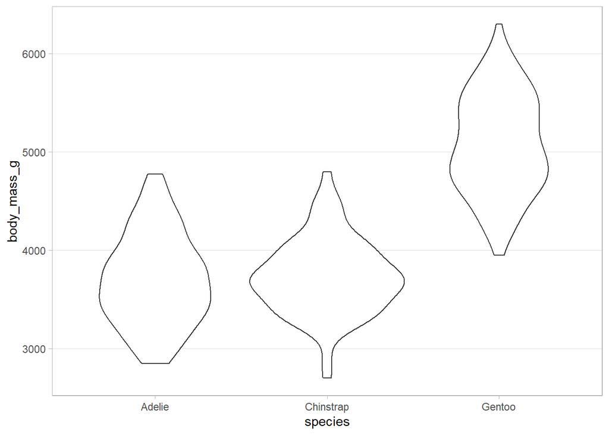

```r
ggplot(penguins, aes(x=species, y=body_mass_g)) +
  geom_violin() +
  theme_light() +
  theme(panel.grid.major.x = element_blank(),
        panel.grid.minor.y = element_blank())
```

### Let’s add mean and CI for mean

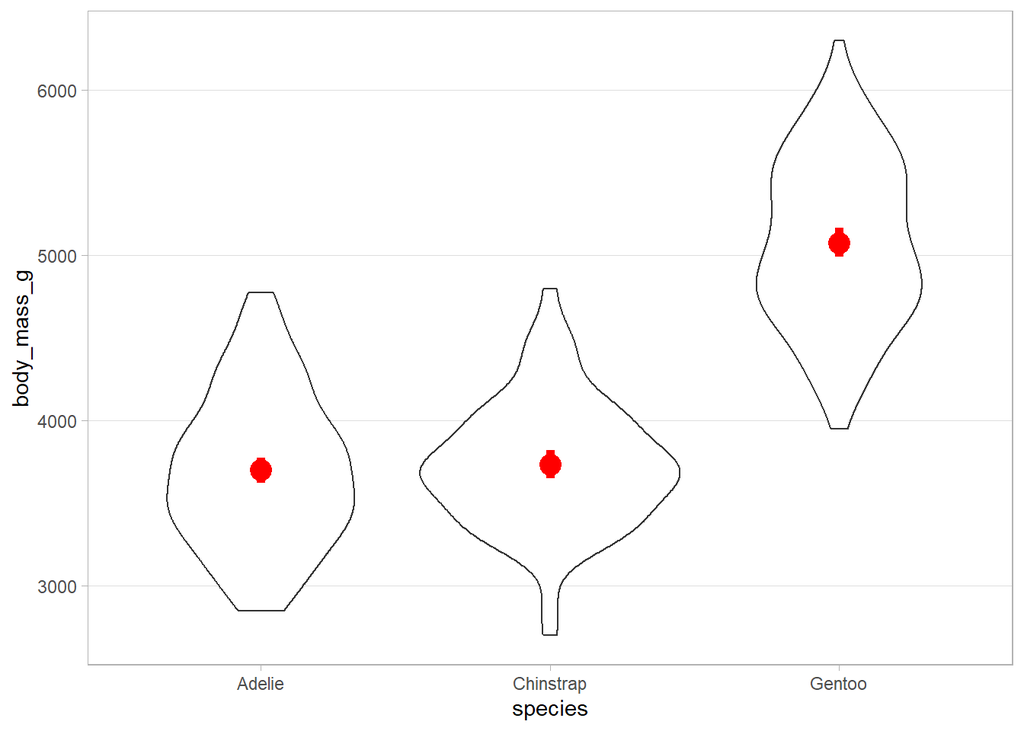

```r
ggplot(penguins, aes(x=species, y=body_mass_g)) +
  geom_violin() +
  stat_summary(fun.data = "mean_cl_boot", color = "red", linewidth = 2, size = 1) +
  theme_light() +
  theme(panel.grid.major.x = element_blank(),
        panel.grid.minor.y = element_blank())
```

### Let’s add some color

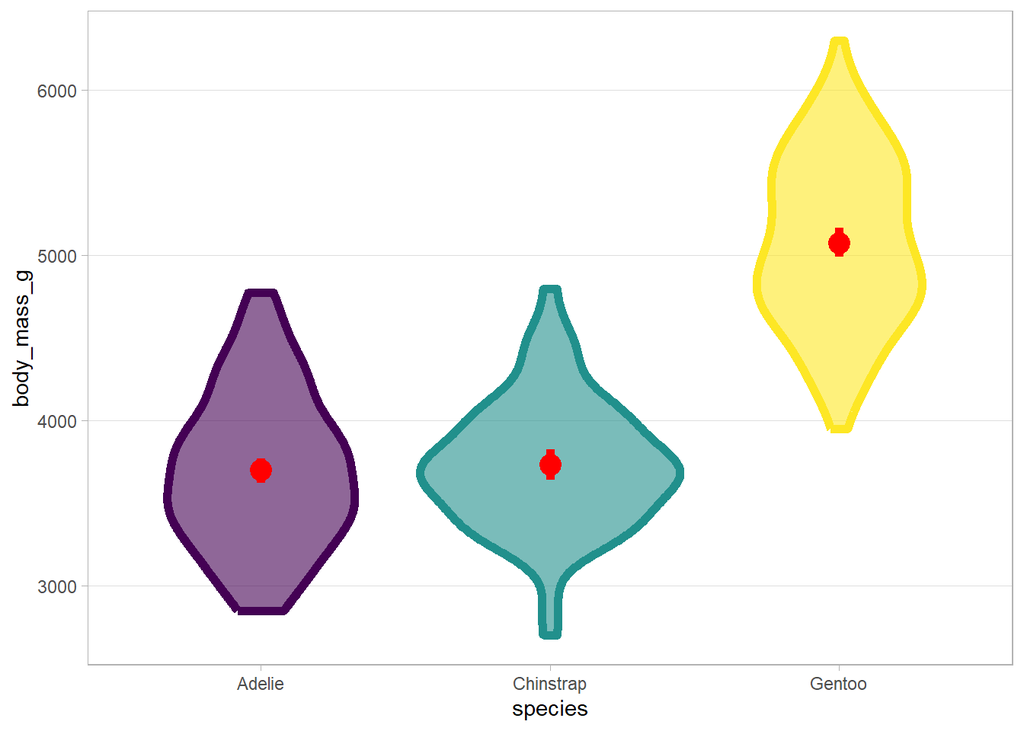

```r
ggplot(penguins, aes(x=species, y=body_mass_g, fill = species, color = species)) +
  geom_violin(alpha = .6, size = 2) +
  stat_summary(fun.data = "mean_cl_boot", color = "red", linewidth = 2, size = 1) +
  scale_color_viridis_d() +
  scale_fill_viridis_d() +
  theme_light() +
  theme(panel.grid.major.x = element_blank(),
        panel.grid.minor.y = element_blank(),
        legend.position = "none")
```

### Let’s change the axis titles

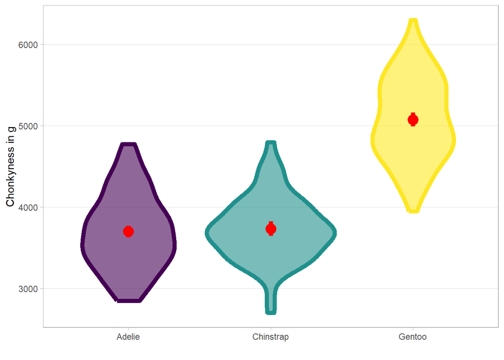

```r
ggplot(penguins, aes(x=species, y=body_mass_g, fill = species, color = species)) +
  geom_violin(alpha = .6, size = 2) +
  stat_summary(fun.data = "mean_cl_boot", color = "red", linewidth = 2, size = 1) +
  xlab("") +
  ylab("Chonkyness in g") +
  scale_color_viridis_d() +
  scale_fill_viridis_d() +
  theme_light() +
  theme(panel.grid.major.x = element_blank(),
        panel.grid.minor.y = element_blank(),
        legend.position = "none")
```

# Plot Two-Way ANOVA

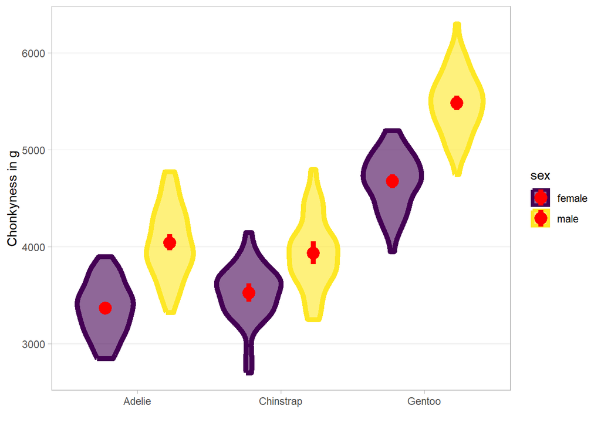

```r
# here I'm just filtering away NAs
penguins_noNA <- penguins |>
    dplyr::filter(!is.na(sex))


ggplot(penguins_noNA, aes(x=species, y=body_mass_g, fill = sex, color = sex)) +
  geom_violin(alpha = .6, size = 2) +
  stat_summary(fun.data = "mean_cl_boot",
               color = "red", linewidth = 2, size = 1,
               position = position_dodge(width = .9)) +
  xlab("") +
  ylab("Chonkyness in g") +
  scale_color_viridis_d() +
  scale_fill_viridis_d() +
  theme_light() +
  theme(panel.grid.major.x = element_blank(),
        panel.grid.minor.y = element_blank())
```

# Conclusion

Gentoo penguins are significantly chonkier than Adelie and Chinstrap penguins.

[figure not shown]

.